# Overview of Statistical Inference

Cheng Peng

West Chester University

# 1 Introduction

Statistical inference is the process of using data analysis to draw conclusions about populations or scientific truths from samples. It allows us to make probabilistic statements about unknown parameters based on observed data.

# 2 Point Estimation

Point estimation involves using sample data to calculate a single value (statistic) that serves as a **best guess** for an unknown population parameter.

**Key Concepts**

- **Estimator**: A rule or formula for calculating an estimate
- **Estimate**: The specific value obtained from a particular sample

Properties of good estimators: Unbiasedness, consistency, efficiency

```r
# Example: Estimating population mean
set.seed(123)
sample_data <- rnorm(100, mean = 50, sd = 10)
point_estimate <- mean(sample_data)
cat("Point estimate of population mean:", round(point_estimate, 2))
```

```
Point estimate of population mean: 50.9
```

**Common Point Estimators**

- Sample mean ($\bar{x}$) for population mean ($\mu$)
- Sample proportion ($\hat{p}$) for population proportion ($p$)
- Sample variance ($s^2$) for population variance ($\sigma^2$)

# 3 Confidence Intervals

Confidence intervals provide a range of plausible values for an unknown population parameter, accompanied by a confidence level that quantifies the uncertainty.

**Interpretation**

A 95% confidence interval means that if we were to take many samples and construct confidence intervals from each, approximately 95% of those intervals would contain the true population parameter.

```r
# 95% Confidence Interval for mean
n <- length(sample_data)
standard_error <- sd(sample_data) / sqrt(n)
margin_error <- qt(0.975, df = n-1) * standard_error
ci_lower <- point_estimate - margin_error
ci_upper <- point_estimate + margin_error

cat("95% Confidence Interval: [", round(ci_lower, 2), ",", round(ci_upper, 2), "]")
```

```
95% Confidence Interval: [ 49.09 , 52.72 ]
```

```r
# Using built-in R function
t_test_result <- t.test(sample_data)
cat("\nUsing t.test():", round(t_test_result$conf.int, 2))
```

```
Using t.test(): 49.09 52.72
```

**Common Confidence Intervals**

- **Mean**: $\bar{x} \pm t_{\alpha/2} \cdot \frac{s}{\sqrt{n}}$
- **Proportion**: $\hat{p} \pm z_{\alpha/2} \cdot \sqrt{\frac{\hat{p}(1-\hat{p})}{n}}$
- **Variance**: $\left[\frac{(n-1)s^2}{\chi^2_{\alpha/2}}, \frac{(n-1)s^2}{\chi^2_{1-\alpha/2}}\right]$

# 4 Hypothesis Testing

Hypothesis testing is a formal procedure for investigating ideas about population parameters using sample data.

**Components**

- **Null hypothesis ($H_0$)**: The default assumption to be tested
- **Alternative hypothesis ($H_1$ or $H_a$)**: The research hypothesis
- **Test statistic**: A standardized value calculated from sample data
- **p-value**: The probability of observing the data if $H_0$ is true
- **Significance level ($\alpha$)**: The threshold for rejecting $H_0$

```r
# One-sample t-test for mean
# H0: μ = 50 vs H1: μ ≠ 50
test_result <- t.test(sample_data, mu = 50)

cat("Test statistic:", round(test_result$statistic, 3), "\n")
```

```
Test statistic: 0.99
```

```r
cat("p-value:", round(test_result$p.value, 4), "\n")
```

```
p-value: 0.3244
```

```r
cat("Conclusion:", ifelse(test_result$p.value < 0.05,
                         "Reject H0", "Fail to reject H0"))
```

```
Conclusion: Fail to reject H0
```

**Types of Tests**

- **One-sample tests**: Compare sample to known parameter
- **Two-sample tests**: Compare two independent samples
- **Paired tests**: Compare related measurements
- **Chi-square tests**: Test for independence or goodness-of-fit

# 5 Bayesian Inference

Bayesian inference provides an alternative framework that incorporates prior beliefs and updates them with observed data using Bayes’ theorem.

**Bayes’ Theorem**

$$P(\theta|X)= \frac{P(X|\theta)P(\theta)}{P(X)}$$

Where:

- $P(\theta|X)$: Posterior distribution
- $P(X|\theta)$: Likelihood function
- $P(\theta)$: Prior distribution
- $P(X)$: Marginal likelihood

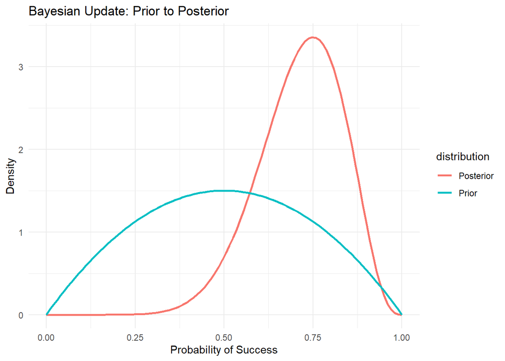

```r
# Simple Bayesian example: Estimating proportion
# Using Beta-Binomial conjugate prior
library(ggplot2)

# Prior: Beta(2,2) - weakly informative
# Data: 8 successes in 10 trials
alpha_prior <- 2
beta_prior <- 2
successes <- 8
trials <- 10

# Posterior: Beta(alpha_prior + successes, beta_prior + failures)
alpha_post <- alpha_prior + successes
beta_post <- beta_prior + (trials - successes)

# Plot prior and posterior
theta <- seq(0, 1, length.out = 100)
prior_dens <- dbeta(theta, alpha_prior, beta_prior)
post_dens <- dbeta(theta, alpha_post, beta_post)

plot_data <- data.frame(
  theta = rep(theta, 2),
  density = c(prior_dens, post_dens),
  distribution = rep(c("Prior", "Posterior"), each = length(theta))
)

ggplot(plot_data, aes(x = theta, y = density, color = distribution)) +
  geom_line(linewidth = 1) +
  labs(title = "Bayesian Update: Prior to Posterior",
       x = "Probability of Success",
       y = "Density") +
  theme_minimal()
```

Resampling methods use repeated sampling from the original data to make statistical inferences, particularly useful when theoretical distributions are unknown or assumptions are violated.

**Bootstrap**

The bootstrap method involves repeatedly sampling with replacement from the original data to estimate the sampling distribution of a statistic.

```r
# Bootstrap confidence interval for mean
set.seed(123)
bootstrap_means <- replicate(1000, {
  bootstrap_sample <- sample(sample_data, size = length(sample_data), replace = TRUE)
  mean(bootstrap_sample)
})

bootstrap_ci <- quantile(bootstrap_means, c(0.025, 0.975))
cat("Bootstrap 95% CI: [", round(bootstrap_ci[1], 2), ",", round(bootstrap_ci[2], 2), "]")
```

```
Bootstrap 95% CI: [ 49.29 , 52.77 ]
```

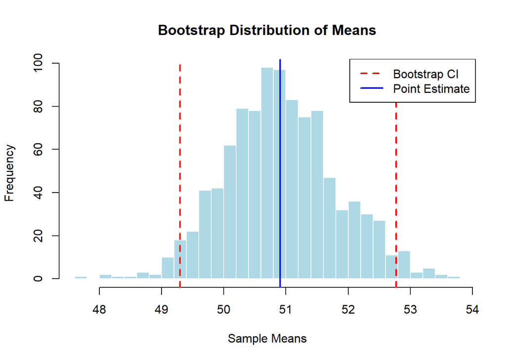

```r
# Plot bootstrap distribution
hist(bootstrap_means, breaks = 30, main = "Bootstrap Distribution of Means",
     xlab = "Sample Means", col = "lightblue", border = "white")
abline(v = bootstrap_ci, col = "red", lty = 2, lwd = 2)
abline(v = point_estimate, col = "blue", lwd = 2)
legend("topright", legend = c("Bootstrap CI", "Point Estimate"),
       col = c("red", "blue"), lty = c(2, 1), lwd = 2)
```

**Cross-Validation**

Used primarily for model assessment and selection by partitioning data into training and validation sets.

# 6 Conclusion

Statistical inference provides the mathematical foundation for drawing conclusions from data in the presence of uncertainty. Each major inference approach has its strengths and appropriate applications:

- Point estimation provides single-value summaries
- Confidence intervals quantify uncertainty around estimates
- Hypothesis testing evaluates specific claims about parameters
- Bayesian inference incorporates prior knowledge and provides probabilistic interpretations
- Resampling methods provide flexible computational approaches

The choice of inference method depends on the research question, data characteristics, and underlying assumptions that can be reasonably made about the population.